# Cognitive data in the UKB

by [Yan Holtz](https://github.com/holtzy/) - 19 January 2018

> This document describes 5 cognitive variables of the UKBiobank dataset: Reasoning (f-20016), Reaction time (‘RT’, f-20023), Numeric memory (f-4282), Visual memory (f-399) and Prospective memory (f-20018). Correlation between variables is evaluated and a PCA is also performed in order to create a G value that summarizes them, as proposed in [Lyall et al](http://journals.plos.org/plosone/article?id=10.1371/journal.pone.0154222).

# 1 Get the data

First of all, I need to load several libraries that will be usefull for our analysis.

```r
library(tidyverse)
library(gridExtra)
library(FactoMineR)
library(rmarkdown)    # You need this library to run this template.
library(epuRate)      # Install with devtools: install_github("holtzy/epuRate", force=TRUE)
```

The UKB dataset is stored in the QBI cluster and thus currently accessible via Inode only. I use a bash command line to recover several fields: id, height, sex, BMI, and the 5 cognitive variables. This file had already been created for Julanne the 11/10/2017. I keep only 50k random lines to have a lighter dataset.

```r
# Go to Julanne folder
cd /ibscratch/wrayvisscher/Yan_Holtz/6_JULANNE_THESIS

# Take the interesting columns
zcat /references/UKBiobank/pheno/download/9280_12505_UKBiobank.tab.gz | cut -f1,2529,2530,2531,3587,2544,2545,2546,2532,2533,2534,163,164,166,167,169,170,171,3452,3453,3454,784,4059,3570,3589,3568,3569,4064,4065,4081,4075,4076,4077,4066,4067,4068,4087,25,9,8,4083,26,27,28,3429,3430,3431,3432,3433,3434,3435,150,151,152,4069,4070,4071,3439,3440,3441,3438,7064,8487,8488,8489,8490,8491,8492,8493,8494,8495,8496,8497,8498,8499,8500,8501,6008,6009,6010,5896,5897,5898,5899,5900,5901 > /clusterdata/uqyholtz/6_JULANNE_THESIS/UKB_Julanne_6_9_2017_full.txt

# Keep 50k random lines and load tranfer the file locally
head -1 UKB_Julanne_6_9_2017_full.txt > UKB_Julanne_6_9_2017_abstract.txt
shuf -n 50000 UKB_Julanne_6_9_2017_full.txt >> UKB_Julanne_6_9_2017_abstract.txt
scp  uqyholtz@inode.qbi.uq.edu.au:/ibscratch/wrayvisscher/Yan_Holtz/6_JULANNE_THESIS/UKB_Julanne_6_9_2017_abstract.txt.gz .
```

This file looks like this:

```r
# Load this file in R
data=read.table("UKB_Julanne_6_9_2017_abstract.txt.gz", header=T)

# Data looks like that
data %>% head(30)
```

|  | f.eid | f.31.0.0 | f.34.0.0 | f.52.0.0 | f.53.0.0 | f.53.1.0 | f.53.2.0 | f.137.0.0 | f.137.1.0 | f.137.2.0 | f.399.0.1 | f.399.0.2 | f.399.1.1 | f.399.1.2 | f.399.2.1 | f.399.2.2 | f.399.2.3 | f.4282.0.0 | f.20016.0.0 | f.20016.1.0 | f.20016.2.0 | f.20018.0.0 | f.20018.1.0 | f.20018.2.0 | f.20023.0.0 | f.20023.1.0 | f.20023.2.0 | f.20115.0.0 | f.20116.0.0 | … |
| --- | --- | --- | --- | --- | --- | --- | --- | --- | --- | --- | --- | --- | --- | --- | --- | --- | --- | --- | --- | --- | --- | --- | --- | --- | --- | --- | --- | --- | --- | --- |
| 1 | 5804756 | 0 | 1940 | 5 | 2008-08-19 | NA | NA | 7 | NA | NA | 0 | 1 | NA | NA | NA | NA | NA | NA | NA | NA | NA | NA | NA | NA | 539 | NA | NA | NA | 1 | … |
| 2 | 4422960 | 0 | 1944 | 1 | 2009-06-15 | NA | 2015-10-24 | 10 | NA | 6 | 0 | 2 | NA | NA | 0 | 6 | 0 | NA | NA | NA | 6 | NA | NA | 1 | 586 | NA | 900 | NA | 1 | … |
| 3 | 1264428 | 0 | 1965 | 12 | 2008-08-09 | 2012-09-29 | 2015-11-24 | 9 | 6 | 3 | 0 | 3 | 0 | 4 | 1 | 1 | 6 | NA | NA | 4 | 7 | NA | 1 | 1 | 402 | 409 | 479 | NA | 0 | … |
| 4 | 1616598 | 1 | 1945 | 8 | 2007-08-14 | NA | NA | 1 | NA | NA | 0 | 3 | NA | NA | NA | NA | NA | NA | NA | NA | NA | NA | NA | NA | 742 | NA | NA | NA | 1 | … |
| 5 | 1900643 | 0 | 1939 | 12 | 2009-03-26 | NA | NA | 0 | NA | NA | 0 | 6 | NA | NA | NA | NA | NA | NA | NA | NA | NA | NA | NA | NA | 668 | NA | NA | NA | 0 | … |
| 6 | 4496510 | 0 | 1948 | 4 | 2008-10-20 | NA | NA | 4 | NA | NA | 0 | 29 | NA | NA | NA | NA | NA | NA | NA | NA | NA | NA | NA | NA | 590 | NA | NA | NA | 1 | … |
| 7 | 5346235 | 1 | 1942 | 4 | 2007-09-01 | NA | NA | 0 | NA | NA | 0 | 12 | NA | NA | NA | NA | NA | NA | NA | NA | NA | NA | NA | NA | 726 | NA | NA | NA | 1 | … |
| 8 | 5245366 | 0 | 1956 | 6 | 2008-12-20 | NA | NA | 1 | NA | NA | 0 | 14 | NA | NA | NA | NA | NA | NA | NA | NA | NA | NA | NA | NA | 458 | NA | NA | 343 | 2 | … |
| 9 | 5339797 | 1 | 1964 | 11 | 2010-01-04 | NA | NA | 4 | NA | NA | 0 | 1 | NA | NA | NA | NA | NA | NA | 9 | NA | NA | 1 | NA | NA | 575 | NA | NA | NA | 2 | … |
| 10 | 4945379 | 0 | 1952 | 4 | 2009-06-05 | NA | NA | 0 | NA | NA | 0 | 6 | NA | NA | NA | NA | NA | NA | NA | NA | NA | NA | NA | NA | 618 | NA | NA | NA | 0 | … |

[output cut: 20 more lines]

This file has 50000 lines and 86 columns. It is ready to be analysed.

# 2 Variables Description

## 2.1 Reasoning

Also called **fluid intelligence** or **verbal-numerical reasoning**. 13 logic-type question have been asked in 2 minutes. Thus the score goes from 0 to 13. Referenced as f-20016 in the UKB. This information is split in 3 columns in the UKB. If I understood well, the first one interests us the most. The other concern a sample of the population who re-done the test about 4 years later. This variable has **16537 entries**. Mean: 5.96. Max: 13. Min: 0. Median: 6. Let’s describe the distribution of this variable.

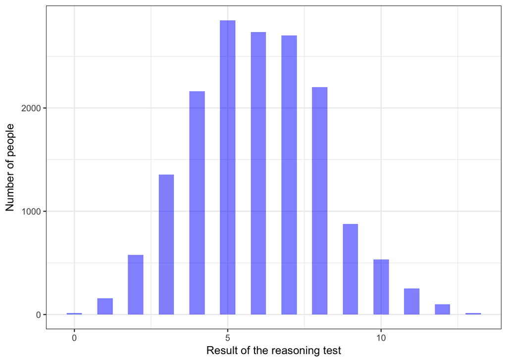

```r
data %>% group_by(f.20016.0.0) %>% summarise(occurence=n()) %>%
  ggplot( aes(x=f.20016.0.0, y=occurence)) +
  geom_bar(stat="identity", fill="blue", alpha=0.5, width=0.5) +
  theme_bw() +
  xlab("Result of the reasoning test") +
  ylab("Number of people")
```

## 2.2 Reaction time

Also called **RT**. Test of symbol matching. The score is the mean reaction time in ms. Thus the smaller the better. Referenced as f-20023 in the UKB. This information is split in 3 columns in the UKB. I use the first (first batch). This variable has **49423 entries** (almost every body). Mean: 560.05. Max: 1938. Min: 172. Median: 539. The distribution of this variable shows a long right tail. We will thus use a log transformation to analyse it as proposed in [Lyall et al.](http://journals.plos.org/plosone/article?id=10.1371/journal.pone.0154222).

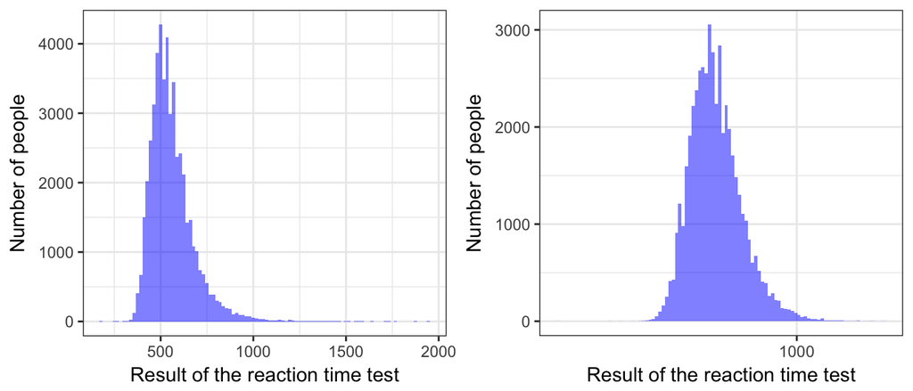

```r
a = data %>%
  ggplot( aes(x=f.20023.0.0)) +
  geom_histogram(fill="blue", alpha=0.5, bins=100) +
  theme_bw() +
  xlab("Result of the reaction time test") +
  ylab("Number of people")
b = a + scale_x_log10()
grid.arrange(a, b, ncol=2)
```

## 2.3 Numeric memory

The score is the number of digits of a number people can remember. It goes from 2 to 12. Thus the bigger the better. Referenced as f-4282 in the UKB. This information is given in 1 column in the UKB. It has not been repeated like the other cognitive variables. It has **5306 entries** (very low proportion of people). Mean: 6.44. Max: 12. Min: -1. Median: 7. The distribution of this variable shows weird value (less than 0) that must be removed for further analysis.

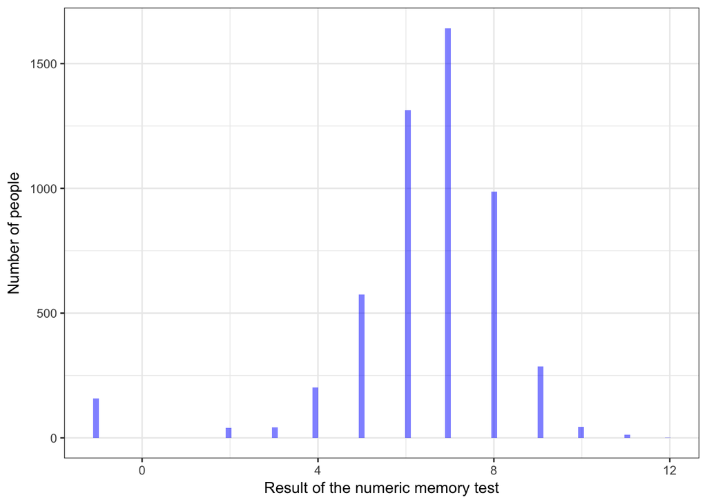

```r
data %>%
  ggplot( aes(x=f.4282.0.0)) +
  geom_histogram(fill="blue", alpha=0.5, bins=100) +
  theme_bw() +
  xlab("Result of the numeric memory test") +
  ylab("Number of people")
```

```r
# Remove weird values under 0
data$f.4282.0.0[ which(data$f.4282.0.0<0)]=NA
```

## 2.4 Visual memory

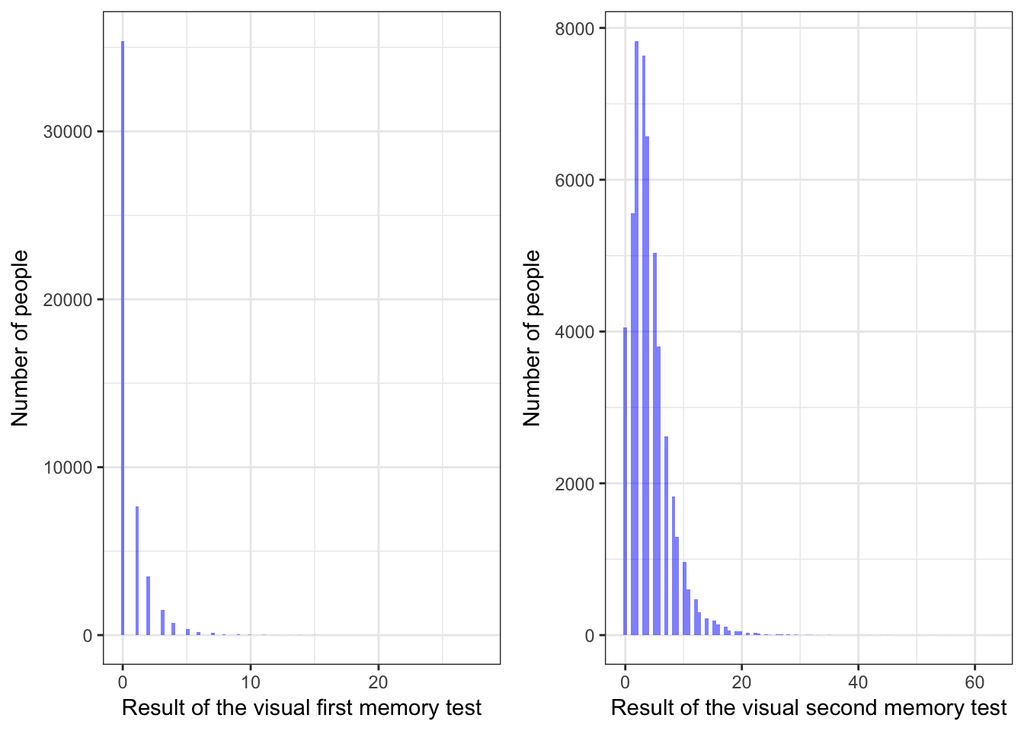

```r
a=data %>%
  ggplot( aes(x=f.399.0.1)) +
  geom_histogram(fill="blue", alpha=0.5, bins=100) +
  theme_bw() +
  xlab("Result of the visual first memory test") +
  ylab("Number of people")
b=data %>%
  ggplot( aes(x=f.399.0.2)) +
  geom_histogram(fill="blue", alpha=0.5, bins=100) +
  theme_bw() +
  xlab("Result of the visual second memory test") +
  ylab("Number of people")
grid.arrange(a, b, ncol=2)
```

## 2.5 Prospective memory

Also called PM. This is a trap at the end of the exam, and the person must remember something we told him at the beginning of the experiment. Result is binary: fail or not. Thus I do not understand why I have 3 categories in my data: 0, 1, 2..? In any case, the number of people evaluated for this test is very low. We probably should **not use** this variable.

```r
table(data$f.20018.0.0) %>% as.data.frame()
```

| Var1 | Freq |
| --- | --- |
| 0 | 874 |
| 1 | 13181 |
| 2 | 3135 |

# 3 Correlation between variable

## 3.1 Table

Let’s compute the Pearson correlation between each pair of the cognitive variables. The values I get are consistent with [Lyall et al.](http://journals.plos.org/plosone/article?id=10.1371/journal.pone.0154222). Except for the prospective memory where I have strange results, probably due to this ‘2’ in the data.

```r
don = data %>% select( f.20016.0.0, f.20023.0.0, f.4282.0.0, f.399.0.1, f.399.0.2, f.20018.0.0)
colnames(don) = c("Reasoning", "Reaction", "Num_memory", "Viz_memory1", "Viz_memory2", "Prosp_memory")
mycor = don %>% cor(use="complete.obs")
mycor %>% round(2) %>% as.data.frame()
```

|  | Reasoning | Reaction | Num_memory | Viz_memory1 | Viz_memory2 | Prosp_memory |
| --- | --- | --- | --- | --- | --- | --- |
| Reasoning | 1.00 | -0.17 | 0.41 | -0.15 | -0.16 | -0.08 |
| Reaction | -0.17 | 1.00 | -0.11 | 0.10 | 0.13 | 0.06 |
| Num_memory | 0.41 | -0.11 | 1.00 | -0.11 | -0.12 | -0.05 |
| Viz_memory1 | -0.15 | 0.10 | -0.11 | 1.00 | 0.11 | 0.07 |
| Viz_memory2 | -0.16 | 0.13 | -0.12 | 0.11 | 1.00 | 0.08 |
| Prosp_memory | -0.08 | 0.06 | -0.05 | 0.07 | 0.08 | 1.00 |

## 3.2 Number of value

When we talk about about correlation between 2 variables, it is important to remember how many data points we have behind each variable.  
In this study, 3 variables have a really low number of data points. We have to keep that in mind concerning the potential use of the G value. If we use these variables in the PCA, the G value will be available for a low number of people.

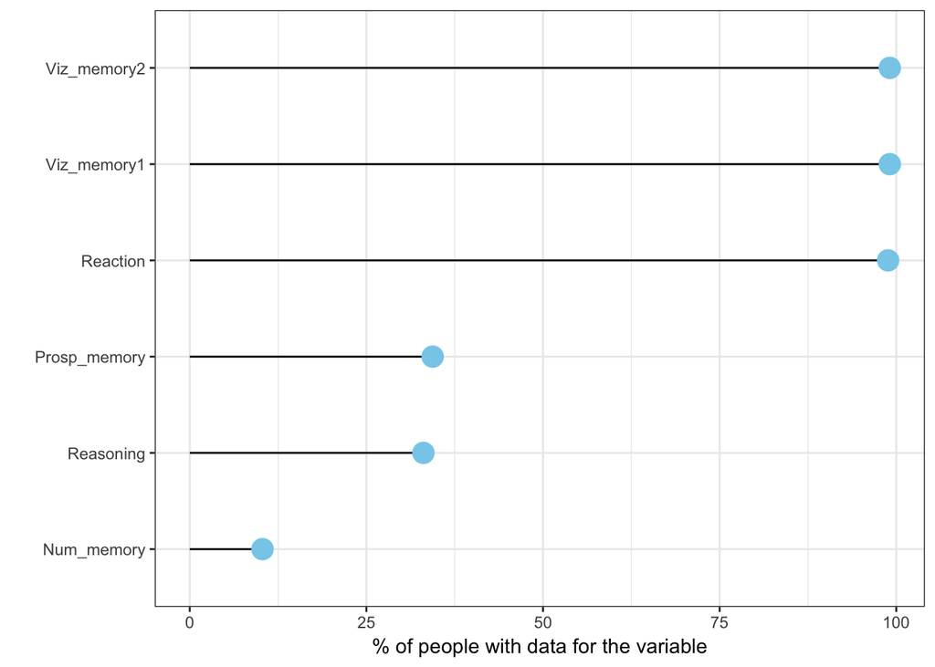

```r
don %>%
  summarise_each(funs(100*mean(!is.na(.)))) %>%
  gather(key=variable, value=value) %>%
  arrange(value) %>%
  mutate(variable=factor(variable, variable)) %>%
  ggplot( aes(x=variable, y=value)) +
    geom_segment( aes(x=variable, xend=variable, y=value, yend=0)) +
    geom_point( color="skyblue", size=5) +
    coord_flip() +
    theme_bw() +
    ylab("% of people with data for the variable") +
    xlab("")
```

## 3.3 Graphic

We can go a bit further showing the relationship between a few pairs of variables.

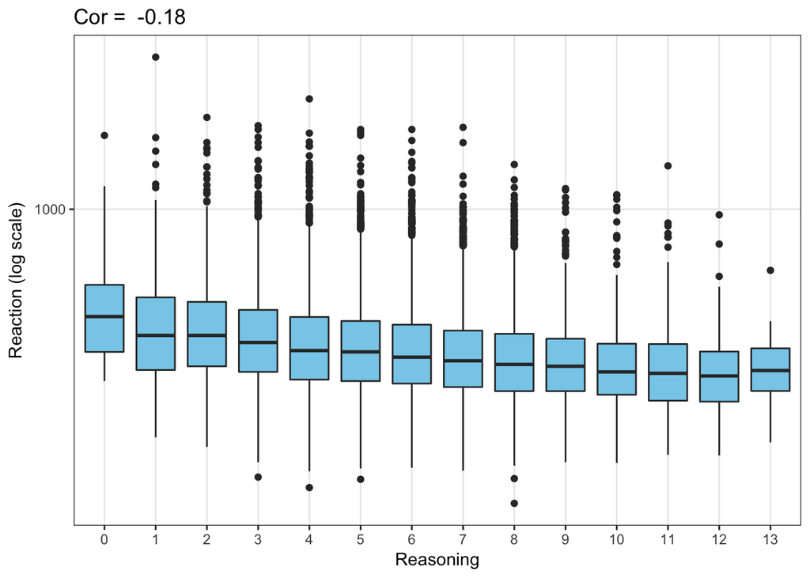

```r
don %>%
  select(Reasoning, Reaction) %>%
  na.omit() %>%
  ggplot( aes( x=as.factor(Reasoning), y=Reaction)) +
    geom_boxplot(fill="skyblue") +
    scale_y_log10() +
    ggtitle( paste("Cor = ", cor(don$Reasoning, don$Reaction, use="complete.obs")%>%round(2))) +
    xlab("Reasoning") +
    ylab("Reaction (log scale)") +
    theme_bw()
```

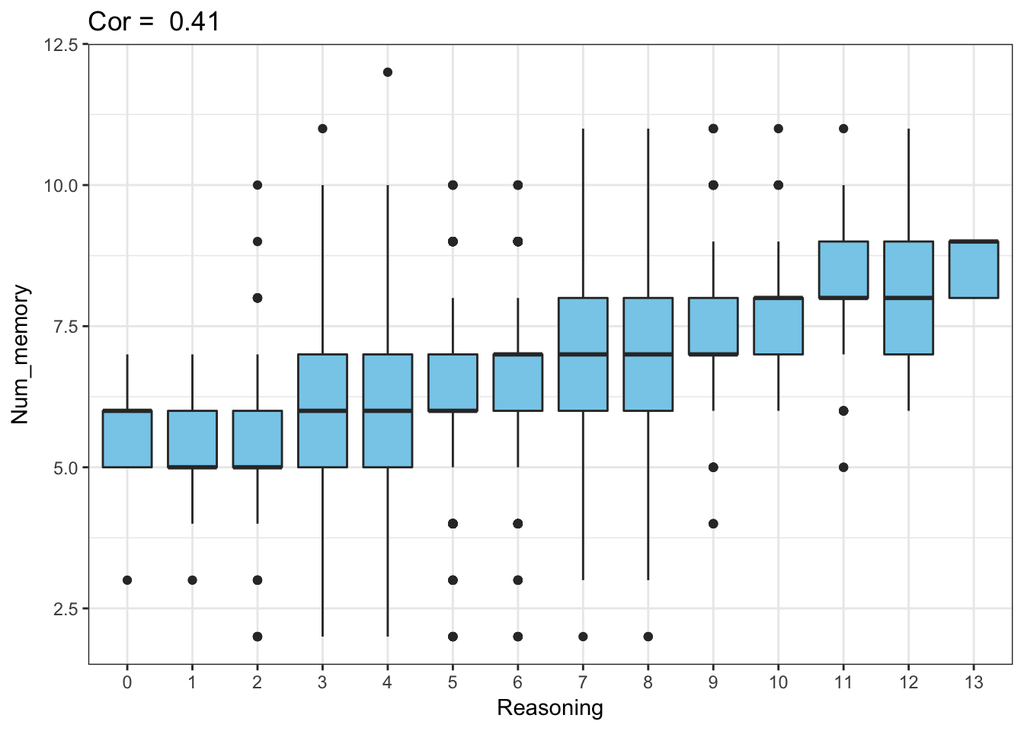

```r
don %>%
  select(Reasoning, Num_memory) %>%
  na.omit() %>%
  ggplot( aes( x=as.factor(Reasoning), y=Num_memory)) +
    geom_boxplot(fill="skyblue") +
    ggtitle( paste("Cor = ", cor(don$Reasoning, don$Num_memory, use="complete.obs")%>%round(2))) +
    xlab("Reasoning") +
    ylab("Num_memory") +
    theme_bw()
```

# 4 PCA and G-value

### 4.0.1 Method

Let’s run a PCA on these data. The goal is to see if we can summarize them through a unique numeric value: a G value.  
Note, I have a lot of NA, I should investigate more how to manage that in the PCA.  
I do not plot the distribution of individuals in the PCA since it makes to many points and the chart gets unreadable.  
Note: Prospective memory is discarded from the PCA as proposed in [Lyall et al.](http://journals.plos.org/plosone/article?id=10.1371/journal.pone.0154222) since it is a binary variable with few entry. Note: I use only the second version of the visual memory

### 4.0.2 Result

The result of the PCA is approximatively consistent with [Lyall et al.](http://journals.plos.org/plosone/article?id=10.1371/journal.pone.0154222):  
- PC1 explain 33% of the variance. They reported 40%. The difference can be due to the fact that they filtered individuals having known psychiatric troubles (I did’nt.)  
- Numerical memory and Reasoning are correlated (0.41), ‘mathematic spirit’ ?  
- Reaction time and Vizual memory are correlated (0.13). Both exercices are visual.  
- It is logical that these 2 pairs of traits are negatively correlated: for the first 2 a high value is a good mark, for the 2 other a low value is a good mark.

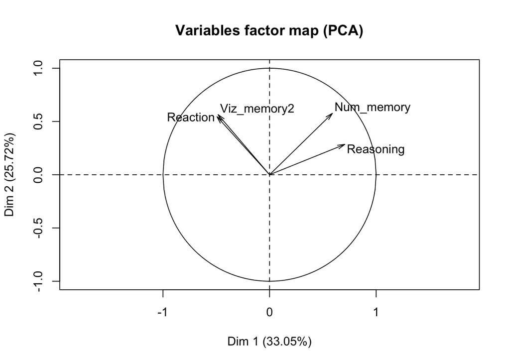

```r
don %>%
  select(-Prosp_memory, -Viz_memory1) %>%
  mutate(Reaction=log(Reaction)) %>%
  mutate(Viz_memory2=log(Viz_memory2+1)) %>%
  PCA(. , scale.unit=TRUE, ncp=4, graph=F ) -> res.PCA
plot.PCA(res.PCA, axes=c(1, 2), choix="var")
```

# 5 Conclusion

The cognitive variables of the UKB are correlated, but there are still significant different between them. The number of people interrogated for each varies a lot. Thus I think that using only a G-value would mean losing a lot of information, knowing that this G value from PCA would be available only for individual with no missing data. This is also what Donald Lyall told me by email.

A work by [Yan Holtz](https://github.com/holtzy/)

*Yan.holtz.data@gmail.com*